# R4DS_2E_dataImport

Martin

2026-01-19

## Data Import - Reading data from a file

1. What function would you use to read a file where fields were separated with “|”?

```r
# We would use `read_delim()` which should hopefully automatically guess what the delimeter is. Else we can specify it. Lets take a look at an example:

read_delim(
  "x|y|z
  1|2|3",
  show_col_types = FALSE
)
```

```
## # A tibble: 1 × 3
##   x         y     z
##   <chr> <dbl> <dbl>
## 1 "  1"     2     3
```

2. Apart from file, skip, and comment, what other arguments do read_csv() and read_tsv() have in common?

```r
# According to the documentation, read_csv and read_tsv arguments are identical
```

3. What are the most important arguments to read_fwf()?

```r
# Given `read_fwf()` reads in data based on the the width of each field I imagine the most important argument is `col_positions`. It uses `fwf_empty()` to guess the col_positions based on the positions of empty columns.
```

4. Sometimes strings in a CSV file contain commas. To prevent them from causing problems, they need to be surrounded by a quoting character, like ” or ’. By default, read_csv() assumes that the quoting character will be “. To read the following text into a data frame, what argument to read_csv() do you need to specify?

```r
read_csv(
  file = "x,y\n1,'a,b'",
  quote = "\'"
)
```

```
## # A tibble: 1 × 2
##       x y
##   <dbl> <chr>
## 1     1 a,b
```

5. Identify what is wrong with each of the following inline CSV files. What happens when you run the code?

```r
read_csv("a,b\n1,2,3\n4,5,6")
```

```
## # A tibble: 2 × 2
##       a     b
##   <dbl> <dbl>
## 1     1    23
## 2     4    56
```

```r
# We have only two variables a & b, but three entries exist on each subsequent row. When running the code, for entries that don't have a respective variable, it puts these entries into the last variable column. They don't have any delimeter between them so the numbers are simply combined e.g. 23, 56.

read_csv("a,b,c\n1,2\n1,2,3,4")
```

```
## # A tibble: 2 × 3
##       a     b     c
##   <dbl> <dbl> <dbl>
## 1     1     2    NA
## 2     1     2    34
```

```r
# Again similar problem to above. The third columns entry on the first row is empty, on the second row, too many values given we have only three variables

read_csv("a,b\n\"1")
```

```
## # A tibble: 0 × 2
## # ℹ 2 variables: a <chr>, b <chr>
```

```r
# Gets confused by the delimeter since we have commas seemingly delimiting between a & b, but we also have a double quotation mark.

read_csv("a,b\n1,2\na,b")
```

```
## # A tibble: 2 × 2
##   a     b
##   <chr> <chr>
## 1 1     2
## 2 a     b
```

```r
# Not sure what the problem is? I guess the column names are also present in the rows entries which is bad.

read_csv("a;b\n1;3")
```

```
## # A tibble: 1 × 1
##   `a;b`
##   <chr>
## 1 1;3
```

```r
# The likelihood is the delimiter is ";" and not part of a string as `read_csv()` sees it. Instead we might have to use a different read function such as `read_csv2()`
```

6. Practice referring to non-syntactic names in the following data frame by:
- Extracting the variable called 1.
- Plotting a scatterplot of 1 vs. 2.
- Creating a new column called 3, which is 2 divided by 1.
- Renaming the columns to one, two, and three.

```r
annoying <- tibble(
  `1` = 1:10,
  `2` = `1` * 2 + rnorm(length(`1`))
)

annoying$`1`
```

```
##  [1]  1  2  3  4  5  6  7  8  9 10
```

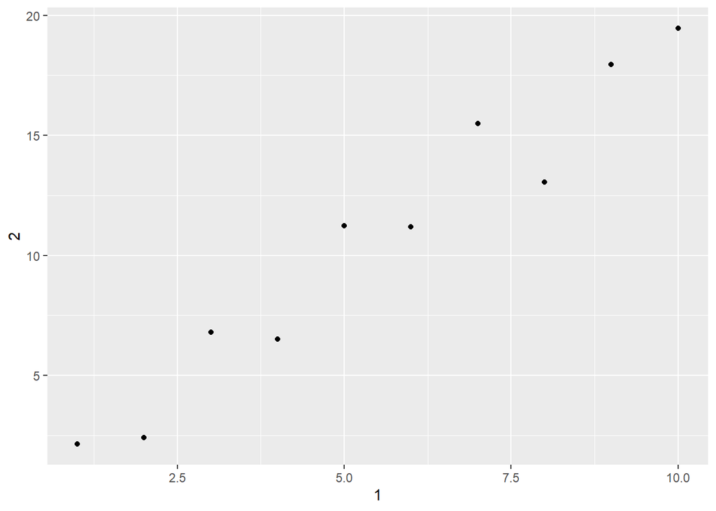

```r
ggplot(annoying, aes(x = `1`, y = `2`)) +
  geom_point()
```

```r
annoying <- annoying |>
  mutate(`3` = `2`/`1`)

annoying |>
  rename(one = `1`, two = `2`, three = `3`)
```

```
## # A tibble: 10 × 3
##      one   two three
##    <int> <dbl> <dbl>
##  1     1  2.14  2.14
##  2     2  2.41  1.20
##  3     3  6.81  2.27
##  4     4  6.52  1.63
##  5     5 11.2   2.25
##  6     6 11.2   1.86
##  7     7 15.5   2.21
##  8     8 13.1   1.63
##  9     9 17.9   1.99
## 10    10 19.5   1.95
```